# Programming Assignment 1 - Reproducible Research

Sangeet Khullar

May 17, 2019

## Read CSV Input

```r
#setwd("C:\\Users\\skhullar\\OneDrive - Daiichi Sankyo\\Documents\\GitHub\\Reproducible_Research")
act <- read.csv("activity.csv")
dim(act)
```

```
## [1] 17568     3
```

## Find Mean & Median Steps Per Day

**1. Sum up all the steps for a given Day - ( Sum(steps) - group by Date )**

**2. Display Histogram of Steps Per Day**

```r
library(dplyr)
```

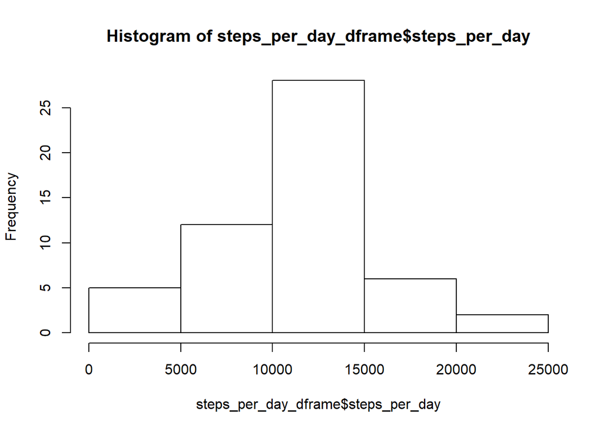

```r
steps_per_day_dframe <- act    %>% group_by(date) %>% summarize(steps_per_day=sum(steps))
hist(steps_per_day_dframe$steps_per_day)
```

**3. Display BarPlot of Steps Per Day**

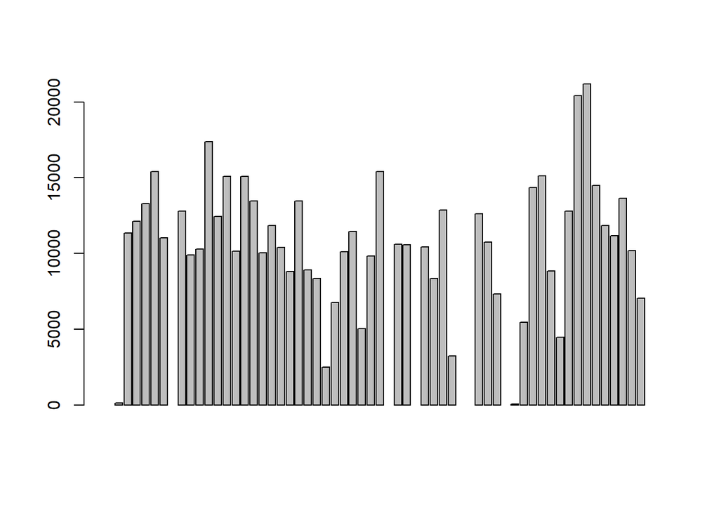

```r
barplot(steps_per_day_dframe$steps_per_day)
```

**4. Find Mean & Median value per day from the above aggregated dataset**

```r
mean_steps_per_day <- steps_per_day_dframe %>% summarize(mean_steps_per_day=mean(steps_per_day,na.rm = TRUE))
print(paste("Mean_Steps_Per_Day=",mean_steps_per_day))
```

```
## [1] "Mean_Steps_Per_Day= 10766.1886792453"
```

```r
median_steps_per_day <- steps_per_day_dframe %>% summarize(median_steps_per_day=median(steps_per_day,na.rm = TRUE))
print(paste("Median_Steps_Per_Day=",median_steps_per_day))
```

```
## [1] "Median_Steps_Per_Day= 10765"
```

## Average daily activity pattern

**1. Time series plot of the 5-minute interval & the average number of steps taken, averaged across all days**

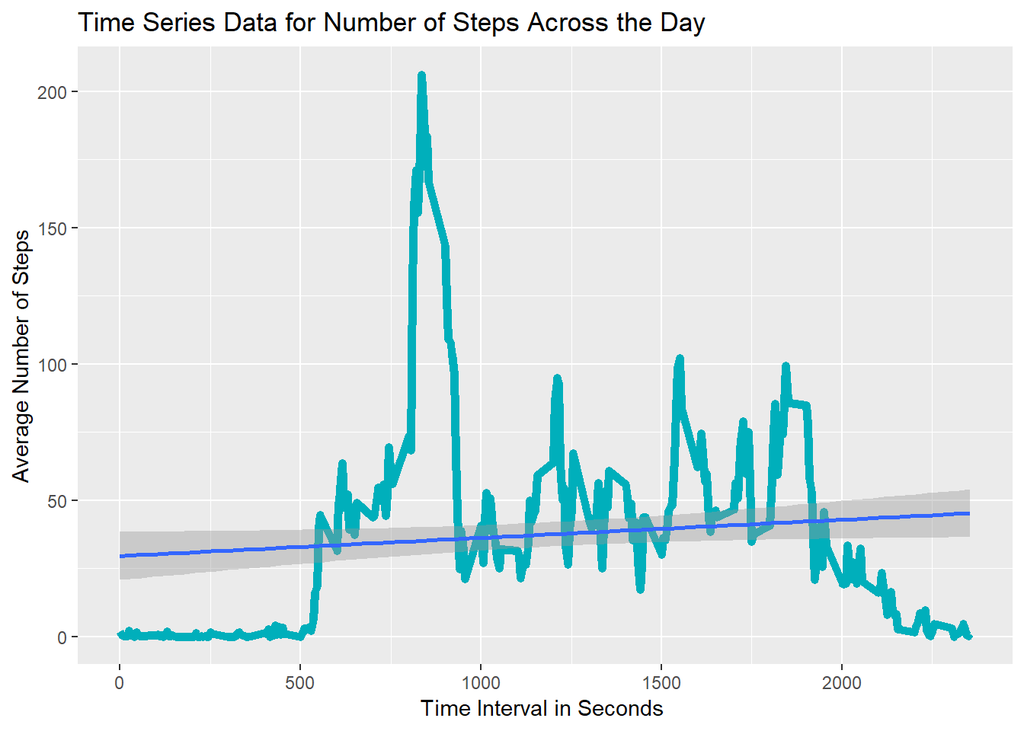

```r
library(ggplot2)
avg_steps_per_5min_interval <- act    %>% group_by(interval) %>% summarize(avg_steps_for_interval= mean(steps,na.rm = TRUE))

ggplot(data = avg_steps_per_5min_interval, aes(x = interval, y = avg_steps_for_interval))+
  geom_line(color = "#00AFBB", size = 2) +
   geom_smooth(method = "lm") +
     labs(x = "Time Interval in Seconds ") +
          labs(y = "Average Number of Steps") +
            labs(title = "Time Series Data for Number of Steps Across the Day")
```

**2. Which 5-minute interval, on average across all the days in the dataset, contains the maximum number of steps?**

```r
max_step_average <- max(avg_steps_per_5min_interval$avg_steps_for_interval, na.rm = TRUE)

max_step_average_interval <- avg_steps_per_5min_interval[which(avg_steps_per_5min_interval$avg_steps_for_interval ==
                                   max_step_average), ]
print(paste("Max_Step_Average_Interval=",max_step_average_interval$interval))
```

```
## [1] "Max_Step_Average_Interval= 835"
```

## Imputing missing values

**Report the total number of missing values in the dataset**

```r
summary(act)
```

```
##      steps                date          interval
##  Min.   :  0.00   2012-10-01:  288   Min.   :   0.0
##  1st Qu.:  0.00   2012-10-02:  288   1st Qu.: 588.8
##  Median :  0.00   2012-10-03:  288   Median :1177.5
##  Mean   : 37.38   2012-10-04:  288   Mean   :1177.5
##  3rd Qu.: 12.00   2012-10-05:  288   3rd Qu.:1766.2
##  Max.   :806.00   2012-10-06:  288   Max.   :2355.0
##  NA's   :2304     (Other)   :15840
```

```r
count_na_values <- sum(is.na(act$steps))
print(paste("Count_Of_Records_With_Missing_Step_Values=",count_na_values))
```

```
## [1] "Count_Of_Records_With_Missing_Step_Values= 2304"
```

**Fill up the missing values in the dataset**

```r
library(mice)
tempData <- mice(act,m=5,maxit=50,meth='pmm',seed=500)
completedData <- complete(tempData,1)
```

**Create a new Data Set with missing values populated**

```r
completedData <- complete(tempData,1)
```

**Make a histogram of the total number of steps taken each day**

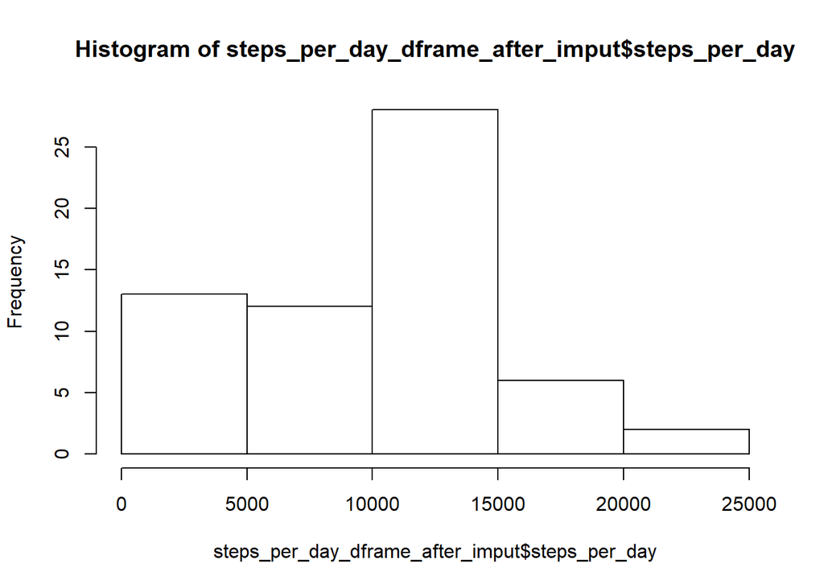

```r
steps_per_day_dframe_after_imput <- completedData    %>% group_by(date) %>% summarize(steps_per_day=sum(steps))
hist(steps_per_day_dframe_after_imput$steps_per_day)
```

**Calculate the mean and median total number of steps taken per day AFTER Imput**

```r
mean_steps_per_day_after_imput  <- steps_per_day_dframe_after_imput %>% summarize(mean_steps_per_day=mean(steps_per_day,na.rm = TRUE))
print(paste("Mean_Steps_Per_Day_After_Imput=",mean_steps_per_day_after_imput))
```

```
## [1] "Mean_Steps_Per_Day_After_Imput= 9354.22950819672"
```

```r
median_steps_per_day_after_imput <- steps_per_day_dframe_after_imput %>% summarize(median_steps_per_day=median(steps_per_day,na.rm = TRUE))
print(paste("Median_Steps_Per_Day_After_Imput=",median_steps_per_day_after_imput))
```

```
## [1] "Median_Steps_Per_Day_After_Imput= 10395"
```

**Mean & Median Before Imput**

```r
print(paste("Mean_Steps_Per_Day_Before_Imput=",mean_steps_per_day))
```

```
## [1] "Mean_Steps_Per_Day_Before_Imput= 10766.1886792453"
```

```r
print(paste("Median_Steps_Per_Day_Before_Imput=",median_steps_per_day))
```

```
## [1] "Median_Steps_Per_Day_Before_Imput= 10765"
```

**Impact of imputing missing data on the estimates of the total daily number of steps**

```r
diff_mean <-  mean_steps_per_day_after_imput -mean_steps_per_day
print(paste("Change_in_Mean_Steps_Per_day=",diff_mean))
```

```
## [1] "Change_in_Mean_Steps_Per_day= -1411.95917104856"
```

```r
diff_median <- median_steps_per_day_after_imput - median_steps_per_day
print(paste("Change_in_Median_Steps_Per_day=",diff_median))
```

```
## [1] "Change_in_Median_Steps_Per_day= -370"
```

## Differences in activity patterns between weekdays and weekends

**New factor variable weekday and weekend**

```r
for (row in 1:nrow(completedData)) {
    day  <- weekdays(as.Date(completedData[row, "date"]))
       if(day %in% c("Monday","Tuesday","Wednesday","Thursday","Friday"))
         {
        completedData[row,"is_Weekday"] <- "1"
         }
        else
          {
        completedData[row,"is_Weekday"] <- "0"
          }
}
```

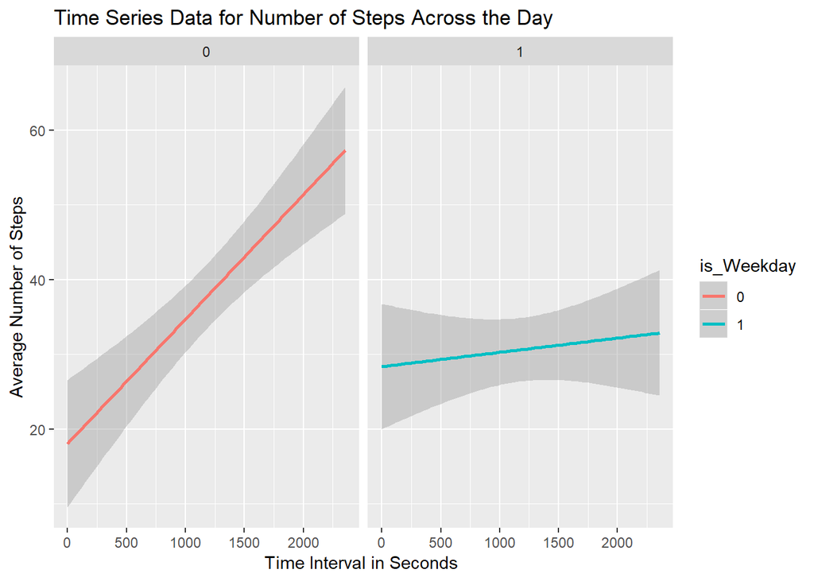

```r
avg_steps_per_5min_interval_imp <- completedData  %>% group_by(interval,is_Weekday) %>%
      summarize(avg_steps_for_interval= mean(steps,na.rm = TRUE))

ggplot(data = avg_steps_per_5min_interval_imp, aes(x = interval, y = avg_steps_for_interval ,color=is_Weekday))+
   facet_grid( .~ is_Weekday) +
    geom_smooth(method = "lm") +
     labs(x = "Time Interval in Seconds ") +
          labs(y = "Average Number of Steps") +
            labs(title = "Time Series Data for Number of Steps Across the Day")
```